# Лабораторная работа №15

Управление логическими томами

Хохлачева Полина Дмитриевна

Российский университет дружбы народов, Москва, Россия

# Информация

## Докладчик

- Хохлачева Полина Дмитриевна
- Российский университет дружбы народов
- Номер студенческого билета- 1132242473
- [1132242473@pfur.ru]

# Вводная часть

## Цель работы

Получить навыки управления логическими томами

## Выполнение лабораторной работы

Хоть 14 лабораторная работа выполнена успешно, но после Rocky отказывался работать, из-за этого пришлось переустанавливать систему, следуя из этого я пропустила первые три пункта и начала с 4(рис. [-@fig:001]).

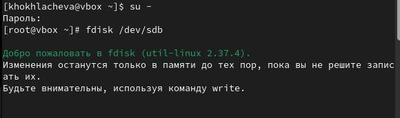

Создание

## Выполнение лабораторной работы

Просмотр текущей разметки, создание новой таблицы, убеждение в удаление, сохранениие [-@fig:002]).

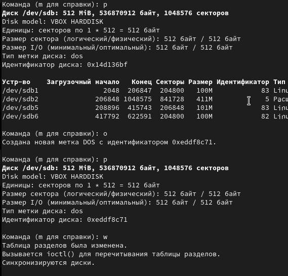

Просмотр

## Выполнение лабораторной работы

Запись изменений, просмотр информации о разделах(рис. [-@fig:003]).

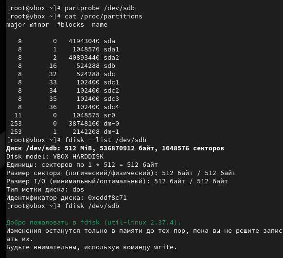

Справка

## Выполнение лабораторной работы

Создание нового раздела, делаем его основным разделом, изменяем тип раздела, записываем изменения, обновляем таблицу разделов, указываем физический том, убеждаемся, что создан успешно(рис. [-@fig:004]).

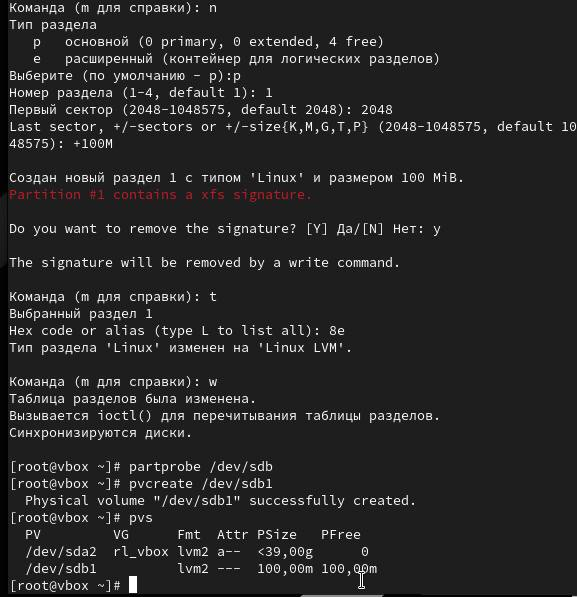

Раздел

## Выполнение лабораторной работы

Проверяем доступность физических томов, создаём группу томов, проверяем, что группа была создана успешно, создаём логический том LVM с именем lvdata, проверка успешного добавления(рис. [-@fig:005]).

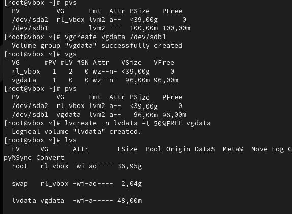

## Выполнение лабораторной работы

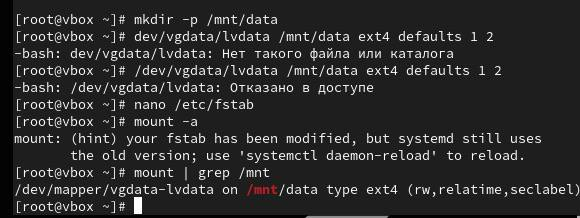

Сравнение

## Выполнение лабораторной работы

Строка, которую мы добавили(рис. [-@fig:007]).

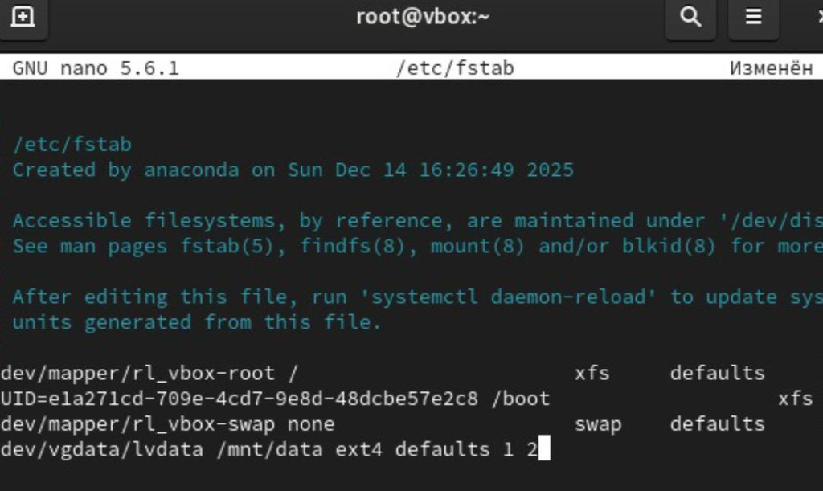

Раздел

## Выполнение лабораторной работы

Добавляем раздел(рис. [-@fig:008]).

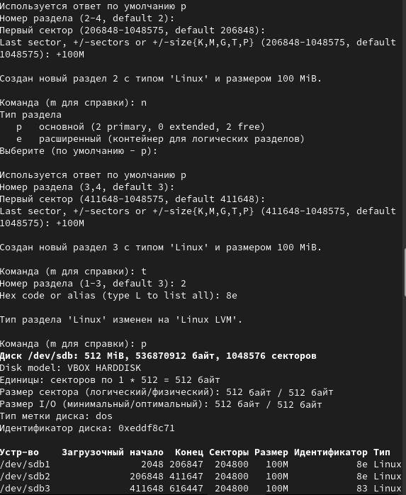

Таблица

## Выполнение лабораторной работы

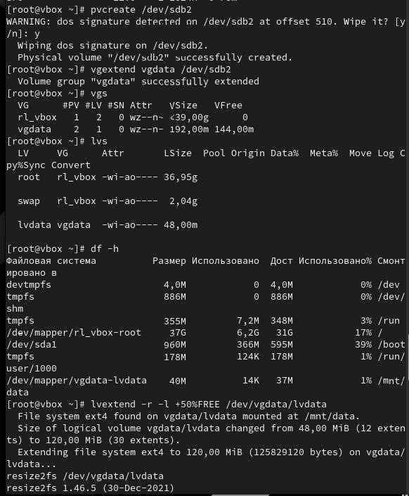

Раздел

## Выполнение лабораторной работы

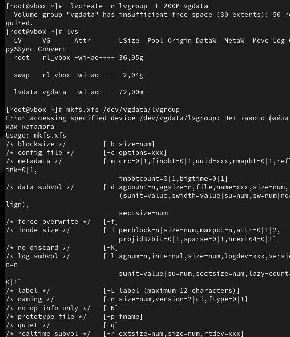

Раздел

## Выполнение лабораторной работы

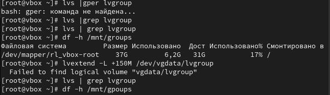

Создание

## Выполнение лабораторной работы

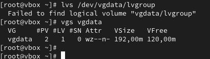

# Выводы

Мы получили навыки управления логическими томами